# Tugas Pertemuan 2

```r
library("forecast")
```

```r
library("graphics")
library("TTR")
library("TSA")
library(rio)
library(readxl)
data1 <- read_excel("C:\\Users\\Mybook Hype7\\Documents\\MPDWW\\MPDWW\\Pertemuan-2\\data suhu bogor 500 akhir.xlsx")
data_me <- data1[101:200, ]
head(data1)
```

```
## # A tibble: 6 × 2
##   time                `temperature_2m_mean (°C)`
##   <dttm>                                   <dbl>
## 1 2025-04-14 00:00:00                       26
## 2 2025-04-15 00:00:00                       24.9
## 3 2025-04-16 00:00:00                       26.2
## 4 2025-04-17 00:00:00                       25.6
## 5 2025-04-18 00:00:00                       26.1
## 6 2025-04-19 00:00:00                       25.7
```

## Eksplorasi Data

`View()` : menampilkan data dalam bentuk tabel, `str()` : menampilkan struktur data, `dim()` : menampilkan dimensi data

```r
View(data_me)
str(data_me)
```

```
## tibble [100 × 2] (S3: tbl_df/tbl/data.frame)
##  $ time                    : POSIXct[1:100], format: "2025-07-23" "2025-07-24" ...
##  $ temperature_2m_mean (°C): num [1:100] 27.1 27.9 27.8 28.4 27.2 26.6 27 27 27.6 27.5 ...
```

```r
dim(data_me)
```

```
## [1] 100   2
```

Mengubah data agar terbaca sebagai data deret waktu dengan fungsi `ts()` .

```r
data_me.ts <- ts(data_me$`temperature_2m_mean (°C)`)
```

Menampilkan ringkasan data

```r
summary(data_me.ts)
```

```
##    Min. 1st Qu.  Median    Mean 3rd Qu.    Max.
##   24.00   25.70   26.45   26.39   27.10   28.40
```

Membuat plot data deret waktu

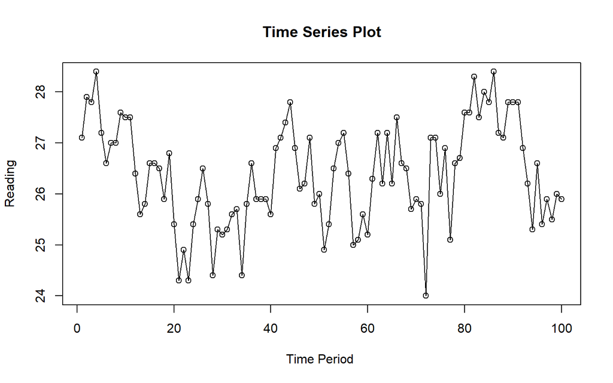

```r
ts.plot(data_me.ts, xlab="Time Period ", ylab="Reading",
        main = "Time Series Plot")
points(data_me.ts)
```

```r
#menyimpan plot
dev.copy(png, "plot_data_me.png")
```

```r
dev.off()
```

```r
library(tseries)
adf.test(data_me.ts)
```

```
##
##  Augmented Dickey-Fuller Test
##
## data:  data_me.ts
## Dickey-Fuller = -2.8617, Lag order = 4, p-value = 0.2197
## alternative hypothesis: stationary
```

## Moving Average

### Pembagian Data

Pembagian data latih dan data uji dilakukan dengan perbandingan 80% data latih dan 20% data uji.

```r
# hitung jumlah data
n <- nrow(data_me)

# tentukan batas 80%
n_train <- floor(0.8 * n)

# bagi data
training_ma <- data_me[1:n_train, ]
testing_ma  <- data_me[(n_train+1):n, ]

# ubah ke time series
train_ma.ts <- ts(training_ma$`temperature_2m_mean (°C)`)
test_ma.ts  <- ts(testing_ma$`temperature_2m_mean (°C)`)
training_ma
```

```
## # A tibble: 80 × 2
##    time                `temperature_2m_mean (°C)`
##    <dttm>                                   <dbl>
##  1 2025-07-23 00:00:00                       27.1
##  2 2025-07-24 00:00:00                       27.9
##  3 2025-07-25 00:00:00                       27.8
##  4 2025-07-26 00:00:00                       28.4
##  5 2025-07-27 00:00:00                       27.2
##  6 2025-07-28 00:00:00                       26.6
##  7 2025-07-29 00:00:00                       27
##  8 2025-07-30 00:00:00                       27
##  9 2025-07-31 00:00:00                       27.6
## 10 2025-08-01 00:00:00                       27.5
## # ℹ 70 more rows
```

```r
testing_ma
```

```
## # A tibble: 20 × 2
##    time                `temperature_2m_mean (°C)`
##    <dttm>                                   <dbl>
##  1 2025-10-11 00:00:00                       27.6
##  2 2025-10-12 00:00:00                       28.3
##  3 2025-10-13 00:00:00                       27.5
##  4 2025-10-14 00:00:00                       28
##  5 2025-10-15 00:00:00                       27.8
##  6 2025-10-16 00:00:00                       28.4
##  7 2025-10-17 00:00:00                       27.2
##  8 2025-10-18 00:00:00                       27.1
##  9 2025-10-19 00:00:00                       27.8
## 10 2025-10-20 00:00:00                       27.8
## 11 2025-10-21 00:00:00                       27.8
## 12 2025-10-22 00:00:00                       26.9
## 13 2025-10-23 00:00:00                       26.2
## 14 2025-10-24 00:00:00                       25.3
## 15 2025-10-25 00:00:00                       26.6
## 16 2025-10-26 00:00:00                       25.4
## 17 2025-10-27 00:00:00                       25.9
## 18 2025-10-28 00:00:00                       25.5
## 19 2025-10-29 00:00:00                       26
## 20 2025-10-30 00:00:00                       25.9
```

Eksplorasi data dilakukan pada keseluruhan data, data latih serta data uji menggunakan plot data deret waktu.

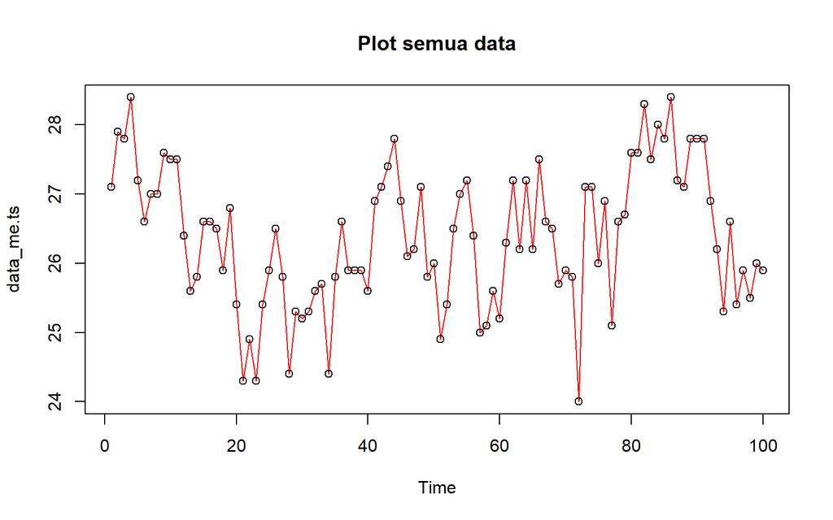

```r
#eksplorasi keseluruhan data
plot(data_me.ts, col="red",main="Plot semua data")
points(data_me.ts)
```

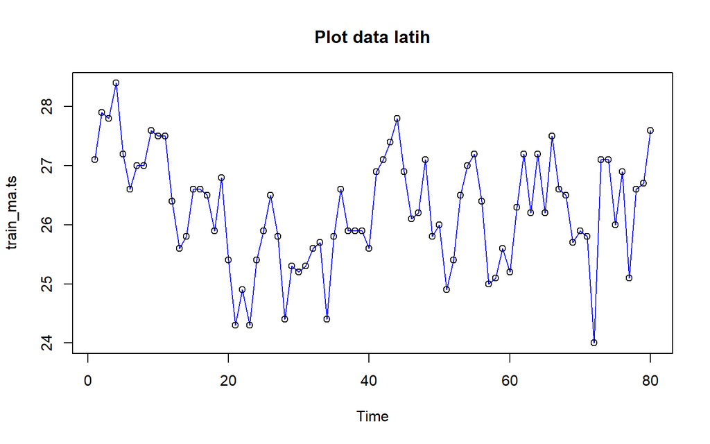

```r
#eksplorasi data latih
plot(train_ma.ts, col="blue",main="Plot data latih")
points(train_ma.ts)
```

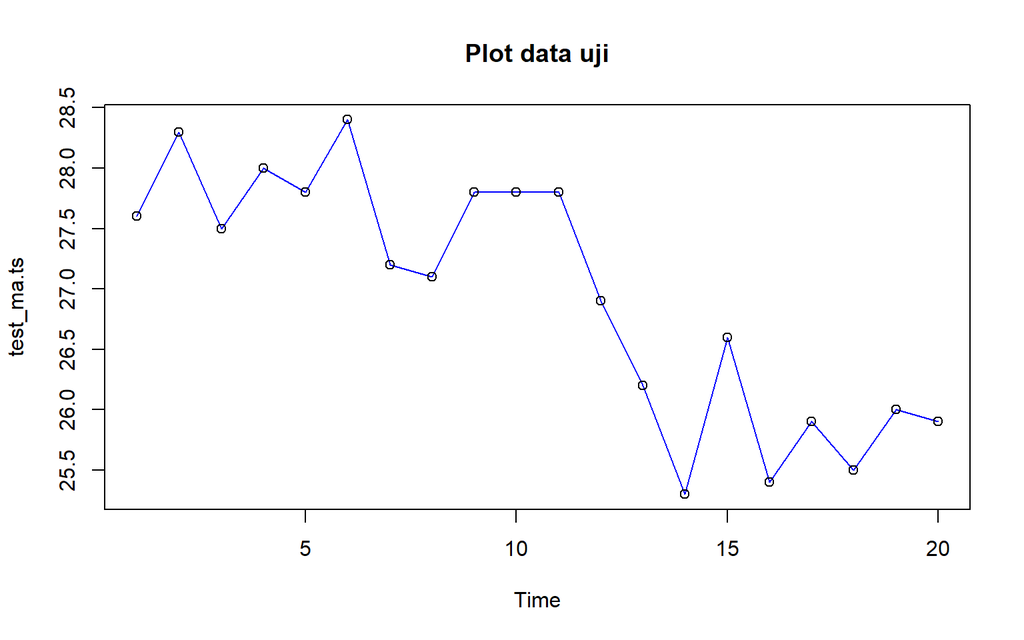

```r
#eksplorasi data uji
plot(test_ma.ts, col="blue",main="Plot data uji")
points(test_ma.ts)
```

### Single Moving Average (SMA)

Pemulusan menggunakan metode SMA dilakukan dengan fungsi `SMA()`. Dalam hal ini akan dilakukan pemulusan dengan parameter `m=4`.

```r
data.sma<-SMA(train_ma.ts, n=4)
data.sma
```

```
## Time Series:
## Start = 1
## End = 80
## Frequency = 1
##  [1]     NA     NA     NA 27.800 27.825 27.500 27.300 26.950 27.050 27.275
## [11] 27.400 27.250 26.750 26.325 26.100 26.150 26.375 26.400 26.450 26.150
## [21] 25.600 25.350 24.725 24.725 25.125 25.525 25.900 25.650 25.500 25.175
## [31] 25.050 25.350 25.450 25.250 25.375 25.625 25.675 26.050 26.075 25.825
## [41] 26.075 26.375 26.750 27.300 27.300 27.050 26.750 26.575 26.300 26.275
## [51] 25.950 25.525 25.700 25.950 26.525 26.775 26.400 25.925 25.525 25.225
## [61] 25.550 26.075 26.225 26.725 26.700 26.775 26.875 26.700 26.575 26.175
## [71] 25.975 25.350 25.700 26.000 26.050 26.775 26.275 26.150 26.325 26.500
```

Data pemulusan pada periode ke-t selanjutnya digunakan sebagai nilai peramalan pada periode ke t+1 sehingga hasil peramalan 1 periode kedepan adalah sebagai berikut.

```r
data.ramal<-c(NA,data.sma)
data.ramal #forecast 1 periode ke depan
```

```
##  [1]     NA     NA     NA     NA 27.800 27.825 27.500 27.300 26.950 27.050
## [11] 27.275 27.400 27.250 26.750 26.325 26.100 26.150 26.375 26.400 26.450
## [21] 26.150 25.600 25.350 24.725 24.725 25.125 25.525 25.900 25.650 25.500
## [31] 25.175 25.050 25.350 25.450 25.250 25.375 25.625 25.675 26.050 26.075
## [41] 25.825 26.075 26.375 26.750 27.300 27.300 27.050 26.750 26.575 26.300
## [51] 26.275 25.950 25.525 25.700 25.950 26.525 26.775 26.400 25.925 25.525
## [61] 25.225 25.550 26.075 26.225 26.725 26.700 26.775 26.875 26.700 26.575
## [71] 26.175 25.975 25.350 25.700 26.000 26.050 26.775 26.275 26.150 26.325
## [81] 26.500
```

```r
data.gab<-cbind(
  aktual=c(data_me.ts),
  pemulusan=c(data.sma,rep(NA,20)),
  ramalan=c(data.ramal,rep(data.ramal[length(data.ramal)],19)))

data.gab #forecast 20 periode ke depan
```

```
##        aktual pemulusan ramalan
##   [1,]   27.1        NA      NA
##   [2,]   27.9        NA      NA
##   [3,]   27.8        NA      NA
##   [4,]   28.4    27.800      NA
##   [5,]   27.2    27.825  27.800
##   [6,]   26.6    27.500  27.825
##   [7,]   27.0    27.300  27.500
##   [8,]   27.0    26.950  27.300
##   [9,]   27.6    27.050  26.950
##  [10,]   27.5    27.275  27.050
##  [11,]   27.5    27.400  27.275
##  [12,]   26.4    27.250  27.400
##  [13,]   25.6    26.750  27.250
##  [14,]   25.8    26.325  26.750
```

[output cut: 86 more lines]

Adapun plot data deret waktu dari hasil peramalan yang dilakukan adalah sebagai berikut.

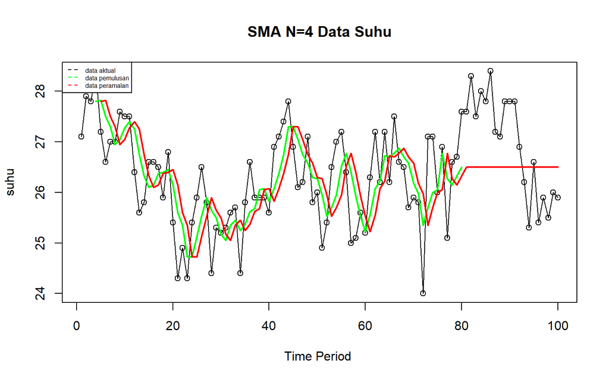

```r
ts.plot(data_me.ts, xlab="Time Period ", ylab="suhu", main= "SMA N=4 Data Suhu")
points(data_me.ts)
lines(data.gab[,2],col="green",lwd=2)
lines(data.gab[,3],col="red",lwd=2)
legend("topleft",c("data aktual","data pemulusan","data peramalan"), lty=8, col=c("black","green","red"), cex=0.5)
```

#### Akurasi Data Latih

```r
#Menghitung nilai keakuratan data latih
error_train.sma = train_ma.ts-data.ramal[1:length(train_ma.ts)]

SSE_train.sma = sum(error_train.sma[5:length(train_ma.ts)]^2)
MSE_train.sma = mean(error_train.sma[5:length(train_ma.ts)]^2)
MAPE_train.sma = mean(abs((error_train.sma[5:length(train_ma.ts)]/train_ma.ts[5:length(train_ma.ts)])*100))

akurasi_train.sma <- matrix(c(SSE_train.sma, MSE_train.sma, MAPE_train.sma))
row.names(akurasi_train.sma)<- c("SSE", "MSE", "MAPE")
colnames(akurasi_train.sma) <- c("Akurasi m = 4")
akurasi_train.sma
```

```
##      Akurasi m = 4
## SSE     65.4093750
## MSE      0.8606497
## MAPE     3.0187099
```

#### Akurasi Data Uji

```r
#Menghitung nilai keakuratan data uji
error_test.sma = test_ma.ts-data.gab[81:100,3]

SSE_test.sma = sum(error_test.sma^2)
MSE_test.sma = mean(error_test.sma^2)
MAPE_test.sma = mean(abs((error_test.sma/test_ma.ts*100)))

akurasi_test.sma <- matrix(c(SSE_test.sma, MSE_test.sma, MAPE_test.sma))
row.names(akurasi_test.sma)<- c("SSE", "MSE", "MAPE")
colnames(akurasi_test.sma) <- c("Akurasi m = 4")
akurasi_test.sma
```

```
##      Akurasi m = 4
## SSE      23.800000
## MSE       1.190000
## MAPE      3.604089
```

Perhitungan akurasi menggunakan data latih menghasilkan nilai MAPE yang kurang dari 10% sehingga nilai akurasi ini dapat dikategorikan sebagai sangat baik.

### Double Moving Average (DMA)

Metode pemulusan Double Moving Average (DMA) pada dasarnya mirip dengan SMA. Namun demikian, metode ini lebih cocok digunakan untuk pola data trend. Proses pemulusan dengan rata rata dalam metode ini dilakukan sebanyak 2 kali.

```r
dma <- SMA(data.sma, n = 4)
At <- 2*data.sma - dma
Bt <- 2/(4-1)*(data.sma - dma)
data.dma<- At+Bt
data.ramal2<- c(NA, data.dma)

t = 1:24
f = c()

for (i in t) {
  f[i] = At[length(At)] + Bt[length(Bt)]*(i)
}

data.gab2 <- cbind(aktual = c(data_me.ts),
                   pemulusan1 = c(data.sma,rep(NA,24)),
                   pemulusan2 = c(dma, rep(NA,24)),
                   At = c(At, rep(NA,24)),
                   Bt = c(Bt,rep(NA,24)),
                   ramalan = c(data.ramal2, f[-1]))
data.gab2
```

```
##        aktual pemulusan1 pemulusan2       At            Bt  ramalan
##   [1,]   27.1         NA         NA       NA            NA       NA
##   [2,]   27.9         NA         NA       NA            NA       NA
##   [3,]   27.8         NA         NA       NA            NA       NA
##   [4,]   28.4     27.800         NA       NA            NA       NA
##   [5,]   27.2     27.825         NA       NA            NA       NA
##   [6,]   26.6     27.500         NA       NA            NA       NA
##   [7,]   27.0     27.300   27.60625 26.99375 -2.041667e-01       NA
##   [8,]   27.0     26.950   27.39375 26.50625 -2.958333e-01 26.78958
##   [9,]   27.6     27.050   27.20000 26.90000 -1.000000e-01 26.21042
##  [10,]   27.5     27.275   27.14375 27.40625  8.750000e-02 26.80000
##  [11,]   27.5     27.400   27.16875 27.63125  1.541667e-01 27.49375
##  [12,]   26.4     27.250   27.24375 27.25625  4.166667e-03 27.78542
##  [13,]   25.6     26.750   27.16875 26.33125 -2.791667e-01 27.26042
##  [14,]   25.8     26.325   26.93125 25.71875 -4.041667e-01 26.05208
```

[output cut: 90 more lines]

Hasil pemulusan menggunakan metode DMA divisualisasikan sebagai berikut

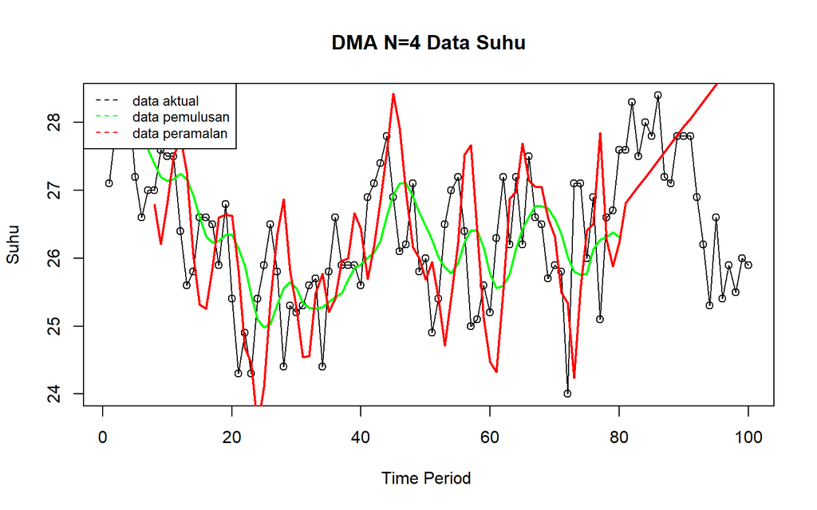

```r
ts.plot(data_me.ts, xlab="Time Period ", ylab="Suhu", main= "DMA N=4 Data Suhu")
points(data_me.ts)
lines(data.gab2[,3],col="green",lwd=2)
lines(data.gab2[,6],col="red",lwd=2)
legend("topleft",c("data aktual","data pemulusan","data peramalan"), lty=8, col=c("black","green","red"), cex=0.8)
```

#### Akurasi Data Latih

```r
#Menghitung nilai keakuratan data latih
error_train.dma = train_ma.ts-data.ramal2[1:length(train_ma.ts)]

SSE_train.dma = sum(error_train.dma[8:length(train_ma.ts)]^2)
MSE_train.dma = mean(error_train.dma[8:length(train_ma.ts)]^2)
MAPE_train.dma = mean(abs((error_train.dma[8:length(train_ma.ts)]/train_ma.ts[8:length(train_ma.ts)])*100))

akurasi_train.dma <- matrix(c(SSE_train.dma, MSE_train.dma, MAPE_train.dma))
row.names(akurasi_train.dma)<- c("SSE", "MSE", "MAPE")
colnames(akurasi_train.dma) <- c("Akurasi m = 4")
akurasi_train.dma
```

```
##      Akurasi m = 4
## SSE      99.414462
## MSE       1.361842
## MAPE      3.640553
```

Perhitungan akurasi pada data latih menggunakan nilai MAPE menghasilkan nilai MAPE yang kurang dari 10% sehingga dikategorikan sangat baik. Selanjutnya, perhitungan nilai akurasi dilakukan pada data uji.

#### Akurasi Data Uji

```r
#Menghitung nilai keakuratan data uji
error_test.dma = test_ma.ts-data.gab2[81:100,6]
SSE_test.dma = sum(error_test.dma^2)
MSE_test.dma = mean(error_test.dma^2)
MAPE_test.dma = mean(abs((error_test.dma/test_ma.ts*100)))

akurasi_test.dma <- matrix(c(SSE_test.dma, MSE_test.dma, MAPE_test.dma))
row.names(akurasi_test.dma)<- c("SSE", "MSE", "MAPE")
colnames(akurasi_test.dma) <- c("Akurasi m = 4")
akurasi_test.dma
```

```
##      Akurasi m = 4
## SSE      76.165625
## MSE       3.808281
## MAPE      5.852808
```

## Exponential Smoothing

Metode Exponential Smoothing merupakan metode pemulusan deret waktu dengan memberikan bobot yang menurun secara eksponensial pada data historis, di mana nilai terbaru mendapat bobot lebih besar dibanding nilai yang lebih lama. Metode ini menggunakan satu atau lebih parameter pemulusan yang secara langsung menentukan besar kecilnya bobot setiap pengamatan. Pemilihan parameter yang tepat akan sangat berpengaruh terhadap hasil ramalan. Secara umum, Exponential Smoothing dibedakan menjadi dua jenis, yaitu model tunggal (single) yang digunakan untuk data tanpa tren maupun musiman, serta model ganda (double) yang mampu menangkap adanya tren pada data.

### Pembagian Data

Pembagian data latih dan data uji dilakukan dengan perbandingan 80% data latih dan 20% data uji.

```r
# jumlah baris data
n <- nrow(data_me)

# hitung batas 80%
n_train <- floor(0.8 * n)

# bagi data
training <- data_me[1:n_train, ]
testing  <- data_me[(n_train+1):n, ]

# ubah ke time series
train.ts <- ts(training$`temperature_2m_mean (°C)`)
test.ts  <- ts(testing$`temperature_2m_mean (°C)`)
```

### Eksplorasi

Eksplorasi dilakukan dengan membuat plot data deret waktu untuk keseluruhan data, data latih, dan data uji.

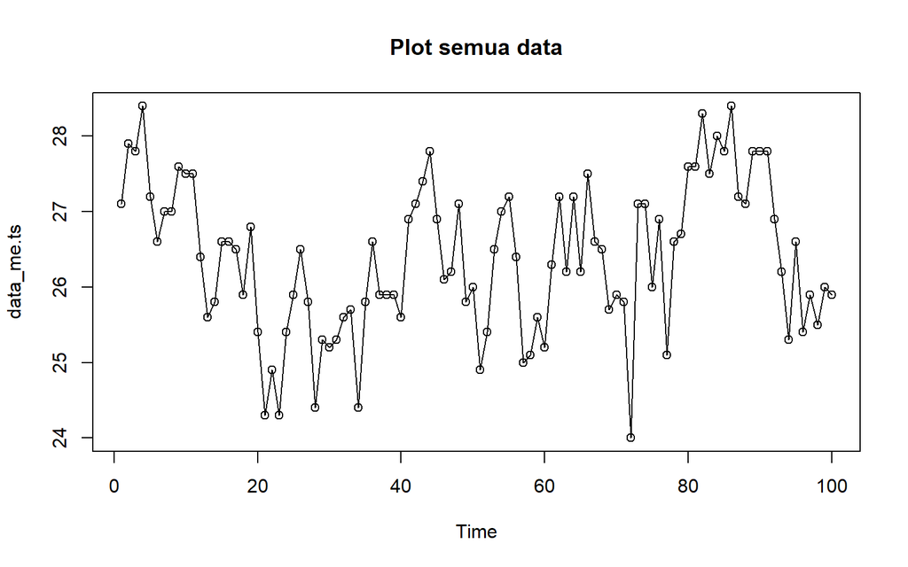

```r
#eksplorasi data
plot(data_me.ts, col="black",main="Plot semua data")
points(data_me.ts)
```

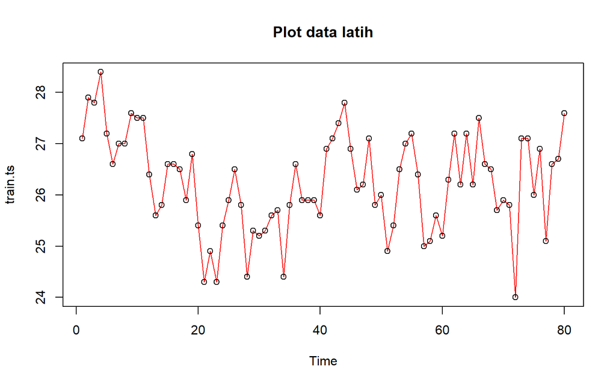

```r
plot(train.ts, col="red",main="Plot data latih")
points(train.ts)
```

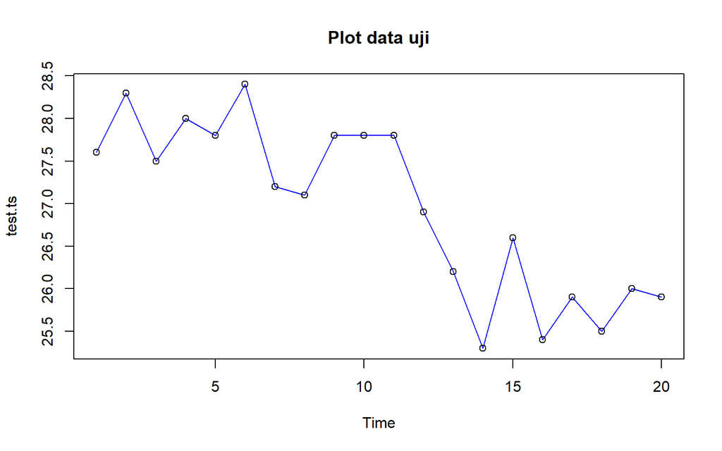

```r
plot(test.ts, col="blue",main="Plot data uji")
points(test.ts)
```

### Single Exponential Smoothing

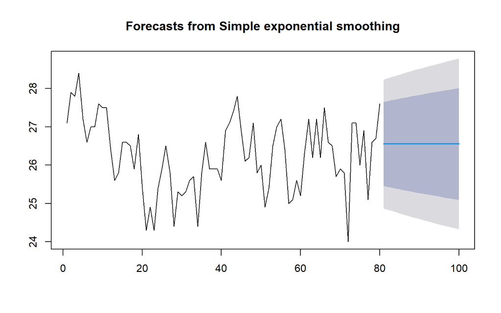

```r
#Cara 1 (fungsi ses)
ses.1 <- ses(train.ts, h = 20, alpha = 0.2)
plot(ses.1)
```

```r
ses.1
```

```
##     Point Forecast    Lo 80    Hi 80    Lo 95    Hi 95
##  81       26.55225 25.45383 27.65067 24.87236 28.23214
##  82       26.55225 25.43207 27.67243 24.83909 28.26541
##  83       26.55225 25.41074 27.69377 24.80645 28.29805
##  84       26.55225 25.38979 27.71471 24.77442 28.33008
##  85       26.55225 25.36921 27.73529 24.74295 28.36155
##  86       26.55225 25.34899 27.75551 24.71202 28.39248
##  87       26.55225 25.32910 27.77540 24.68160 28.42290
##  88       26.55225 25.30953 27.79498 24.65167 28.45283
##  89       26.55225 25.29026 27.81424 24.62220 28.48230
##  90       26.55225 25.27128 27.83322 24.59318 28.51133
##  91       26.55225 25.25258 27.85192 24.56457 28.53993
##  92       26.55225 25.23414 27.87036 24.53638 28.56812
##  93       26.55225 25.21596 27.88854 24.50857 28.59593
##  94       26.55225 25.19802 27.90648 24.48114 28.62336
##  95       26.55225 25.18032 27.92418 24.45406 28.65044
##  96       26.55225 25.16284 27.94166 24.42733 28.67717
##  97       26.55225 25.14558 27.95892 24.40094 28.70356
##  98       26.55225 25.12853 27.97597 24.37486 28.72964
##  99       26.55225 25.11168 27.99282 24.34909 28.75541
## 100       26.55225 25.09503 28.00947 24.32362 28.78088
```

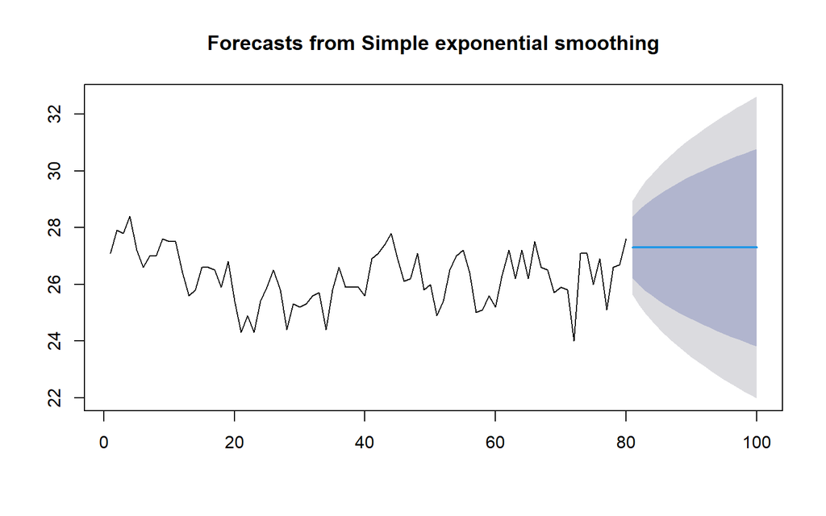

```r
ses.2<- ses(train.ts, h = 20, alpha = 0.7)
plot(ses.2)
```

```r
ses.2
```

```
##     Point Forecast    Lo 80    Hi 80    Lo 95    Hi 95
##  81       27.29353 26.20936 28.37770 25.63543 28.95162
##  82       27.29353 25.97013 28.61692 25.26957 29.31749
##  83       27.29353 25.76797 28.81909 24.96038 29.62667
##  84       27.29353 25.58962 28.99743 24.68763 29.89942
##  85       27.29353 25.42825 29.15880 24.44084 30.14622
##  86       27.29353 25.27977 29.30728 24.21376 30.37330
##  87       27.29353 25.14151 29.44554 24.00231 30.58475
##  88       27.29353 25.01162 29.57544 23.80365 30.78341
##  89       27.29353 24.88873 29.69833 23.61570 30.97136
##  90       27.29353 24.77182 29.81524 23.43690 31.15015
##  91       27.29353 24.66009 29.92696 23.26603 31.32102
##  92       27.29353 24.55292 30.03414 23.10213 31.48493
##  93       27.29353 24.44978 30.13728 22.94439 31.64266
##  94       27.29353 24.35025 30.23680 22.79218 31.79488
##  95       27.29353 24.25399 30.33307 22.64495 31.94211
##  96       27.29353 24.16067 30.42638 22.50224 32.08481
##  97       27.29353 24.07006 30.51699 22.36366 32.22339
##  98       27.29353 23.98193 30.60513 22.22888 32.35818
##  99       27.29353 23.89608 30.69097 22.09758 32.48947
## 100       27.29353 23.81235 30.77470 21.96953 32.61753
```

Selanjutnya akan digunakan fungsi `HoltWinters()` dengan nilai inisialisasi parameter dan panjang periode peramalan yang sama dengan fungsi `ses()` .

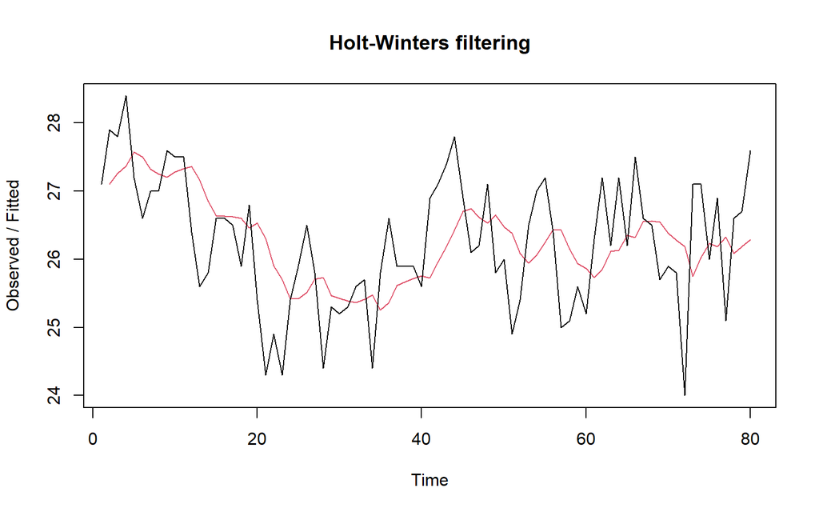

```r
#Cara 2 (fungsi Holtwinter)
ses1<- HoltWinters(train.ts, gamma = FALSE, beta = FALSE, alpha = 0.2)
plot(ses1)
```

```r
#ramalan
ramalan1<- forecast(ses1, h=20)
ramalan1
```

```
##     Point Forecast    Lo 80    Hi 80    Lo 95    Hi 95
##  81       26.55225 25.45294 27.65156 24.87100 28.23350
##  82       26.55225 25.43117 27.67333 24.83771 28.26680
##  83       26.55225 25.40981 27.69469 24.80504 28.29946
##  84       26.55225 25.38885 27.71565 24.77298 28.33152
##  85       26.55225 25.36826 27.73624 24.74149 28.36301
##  86       26.55225 25.34802 27.75649 24.71053 28.39397
##  87       26.55225 25.32811 27.77639 24.68009 28.42441
##  88       26.55225 25.30852 27.79598 24.65013 28.45437
##  89       26.55225 25.28924 27.81526 24.62064 28.48386
##  90       26.55225 25.27025 27.83426 24.59159 28.51291
##  91       26.55225 25.25153 27.85297 24.56297 28.54153
##  92       26.55225 25.23308 27.87142 24.53475 28.56975
##  93       26.55225 25.21488 27.88962 24.50692 28.59758
##  94       26.55225 25.19693 27.90757 24.47947 28.62504
##  95       26.55225 25.17921 27.92529 24.45237 28.65213
##  96       26.55225 25.16172 27.94278 24.42562 28.67888
##  97       26.55225 25.14445 27.96006 24.39920 28.70530
##  98       26.55225 25.12738 27.97712 24.37310 28.73140
##  99       26.55225 25.11052 27.99398 24.34731 28.75719
## 100       26.55225 25.09385 28.01065 24.32182 28.78268
```

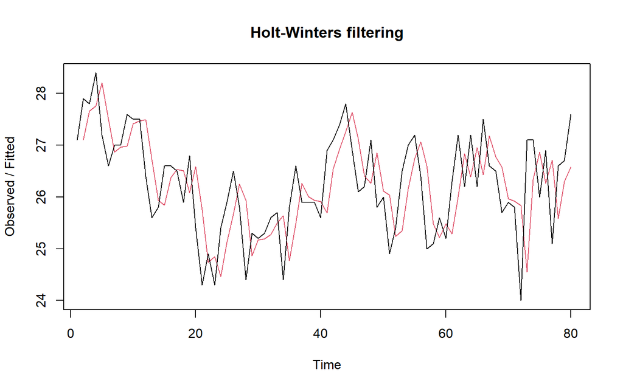

```r
ses2<- HoltWinters(train.ts, gamma = FALSE, beta = FALSE, alpha = 0.7)
plot(ses2)
```

```r
#ramalan
ramalan2<- forecast(ses2, h=20)
ramalan2
```

```
##     Point Forecast    Lo 80    Hi 80    Lo 95    Hi 95
##  81       27.29353 26.20877 28.37828 25.63454 28.95252
##  82       27.29353 25.96942 28.61764 25.26847 29.31858
##  83       27.29353 25.76714 28.81991 24.95912 29.62793
##  84       27.29353 25.58870 28.99835 24.68622 29.90083
##  85       27.29353 25.42724 29.15981 24.43929 30.14776
##  86       27.29353 25.27868 29.30837 24.21209 30.37496
##  87       27.29353 25.14035 29.44670 24.00053 30.58653
##  88       27.29353 25.01038 29.57667 23.80176 30.78530
##  89       27.29353 24.88742 29.69963 23.61371 30.97334
##  90       27.29353 24.77045 29.81660 23.43482 31.15224
##  91       27.29353 24.65867 29.92839 23.26386 31.32320
##  92       27.29353 24.55144 30.03562 23.09986 31.48720
##  93       27.29353 24.44824 30.13881 22.94204 31.64502
##  94       27.29353 24.34866 30.23839 22.78974 31.79731
##  95       27.29353 24.25234 30.33471 22.64244 31.94462
##  96       27.29353 24.15898 30.42808 22.49965 32.08741
##  97       27.29353 24.06832 30.51874 22.36100 32.22606
##  98       27.29353 23.98014 30.60692 22.22614 32.36092
##  99       27.29353 23.89424 30.69281 22.09477 32.49228
## 100       27.29353 23.81047 30.77659 21.96665 32.62041
```

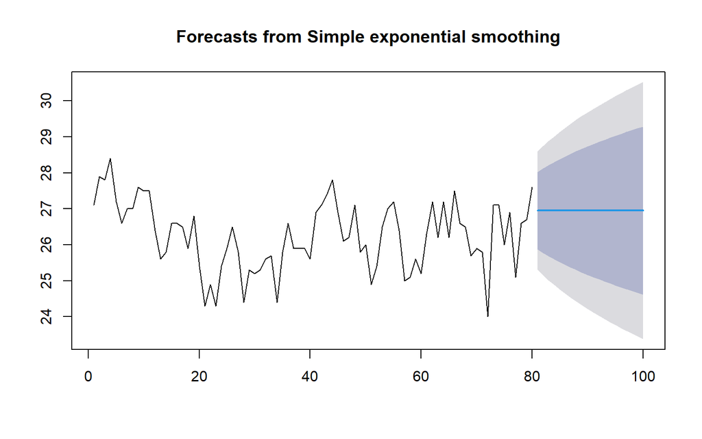

```r
#SES
ses.opt <- ses(train.ts, h = 20, alpha = NULL)
plot(ses.opt)
```

```r
ses.opt
```

```
##     Point Forecast    Lo 80    Hi 80    Lo 95    Hi 95
##  81       26.94952 25.87806 28.02097 25.31086 28.58817
##  82       26.94952 25.77710 28.12193 25.15646 28.74257
##  83       26.94952 25.68417 28.21486 25.01434 28.88469
##  84       26.94952 25.59762 28.30142 24.88196 29.01707
##  85       26.94952 25.51628 28.38275 24.75757 29.14146
##  86       26.94952 25.43931 28.45972 24.63986 29.25917
##  87       26.94952 25.36609 28.53294 24.52787 29.37116
##  88       26.94952 25.29610 28.60293 24.42084 29.47820
##  89       26.94952 25.22896 28.67007 24.31815 29.58088
##  90       26.94952 25.16434 28.73469 24.21932 29.67971
##  91       26.94952 25.10198 28.79705 24.12395 29.77508
##  92       26.94952 25.04166 28.85738 24.03170 29.86734
##  93       26.94952 24.98318 28.91585 23.94227 29.95676
##  94       26.94952 24.92640 28.97263 23.85542 30.04361
##  95       26.94952 24.87117 29.02787 23.77095 30.12808
##  96       26.94952 24.81736 29.08167 23.68867 30.21036
##  97       26.94952 24.76488 29.13415 23.60841 30.29062
##  98       26.94952 24.71364 29.18540 23.53003 30.36900
##  99       26.94952 24.66354 29.23549 23.45342 30.44562
## 100       26.94952 24.61452 29.28452 23.37844 30.52059
```

```r
#Lamda Optimum Holt Winter
HWopt<- HoltWinters(train.ts, gamma = FALSE, beta = FALSE,alpha = NULL)
HWopt
```

```
## Holt-Winters exponential smoothing without trend and without seasonal component.
##
## Call:
## HoltWinters(x = train.ts, alpha = NULL, beta = FALSE, gamma = FALSE)
##
## Smoothing parameters:
##  alpha: 0.4604202
##  beta : FALSE
##  gamma: FALSE
##
## Coefficients:
##       [,1]
## a 26.97345
```

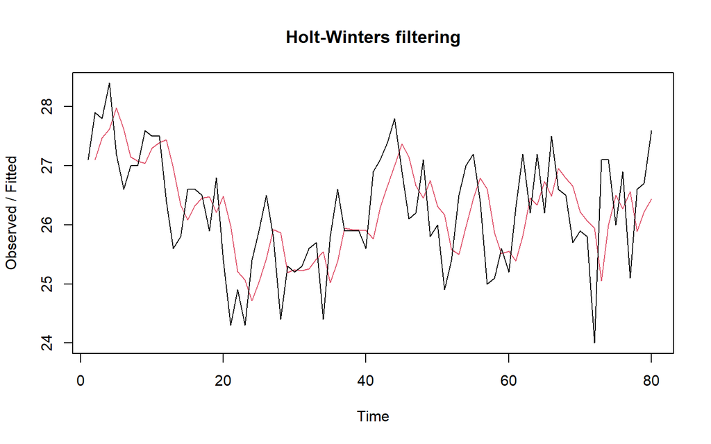

```r
plot(HWopt)
```

```r
#ramalan
ramalanopt<- forecast(HWopt, h=20)
ramalanopt
```

```
##     Point Forecast    Lo 80    Hi 80    Lo 95    Hi 95
##  81       26.97345 25.89995 28.04695 25.33167 28.61523
##  82       26.97345 25.79163 28.15527 25.16601 28.78089
##  83       26.97345 25.69244 28.25446 25.01431 28.93259
##  84       26.97345 25.60039 28.34651 24.87354 29.07336
##  85       26.97345 25.51414 28.43276 24.74163 29.20527
##  86       26.97345 25.43271 28.51419 24.61709 29.32981
##  87       26.97345 25.35537 28.59153 24.49882 29.44809
##  88       26.97345 25.28157 28.66533 24.38594 29.56096
##  89       26.97345 25.21085 28.73605 24.27778 29.66912
##  90       26.97345 25.14286 28.80404 24.17381 29.77310
##  91       26.97345 25.07731 28.86959 24.07355 29.87335
##  92       26.97345 25.01395 28.93295 23.97665 29.97025
##  93       26.97345 24.95257 28.99433 23.88279 30.06412
##  94       26.97345 24.89301 29.05389 23.79169 30.15521
##  95       26.97345 24.83510 29.11180 23.70313 30.24377
##  96       26.97345 24.77872 29.16818 23.61691 30.33000
##  97       26.97345 24.72376 29.22314 23.53284 30.41406
##  98       26.97345 24.67010 29.27680 23.45078 30.49612
##  99       26.97345 24.61767 29.32923 23.37059 30.57631
## 100       26.97345 24.56638 29.38053 23.29215 30.65475
```

#### Akurasi Data Latih

Perhitungan akurasi data dapat dilakukan dengan cara langsung maupun manual. Secara langsung, nilai akurasi dapat diambil dari objek yang tersimpan pada hasil SES, yaitu *sum of squared errors* (SSE). Nilai akurasi lain dapat dihitung pula dari nilai SSE tersebut.

```r
#Keakuratan Metode
#Pada data training

# SES dengan alpha = 0.2
SSE1<-ses1$SSE
MSE1<-ses1$SSE/length(train.ts)
RMSE1<-sqrt(MSE1)

akurasi1 <- matrix(c(SSE1,MSE1,RMSE1))
row.names(akurasi1)<- c("SSE", "MSE", "RMSE")
colnames(akurasi1) <- c("Akurasi lamda=0.2")
akurasi1
```

```
##      Akurasi lamda=0.2
## SSE         57.4885031
## MSE          0.7186063
## RMSE         0.8477065
```

```r
# SES dengan alpha = 0.7
SSE2<-ses2$SSE
MSE2<-ses2$SSE/length(train.ts)
RMSE2<-sqrt(MSE2)

akurasi2 <- matrix(c(SSE2,MSE2,RMSE2))
row.names(akurasi2)<- c("SSE", "MSE", "RMSE")
colnames(akurasi2) <- c("Akurasi lamda=0.7")
akurasi2
```

```
##      Akurasi lamda=0.7
## SSE         55.8847527
## MSE          0.6985594
## RMSE         0.8357987
```

```r
#Cara Manual
# Alpha = 0.2
fitted1<-ramalan1$fitted
sisaan1<-ramalan1$residuals
head(sisaan1)
```

```
## Time Series:
## Start = 1
## End = 6
## Frequency = 1
## [1]       NA  0.80000  0.54000  1.03200 -0.37440 -0.89952
```

```r
resid1<-training$`temperature_2m_mean (°C)`-ramalan1$fitted
head(resid1)
```

```
## Time Series:
## Start = 1
## End = 6
## Frequency = 1
## [1]       NA  0.80000  0.54000  1.03200 -0.37440 -0.89952
```

```r
SSE.1=sum(sisaan1[2:length(train.ts)]^2)
SSE.1
```

```
## [1] 57.4885
```

```r
MSE.1 = SSE.1/length(train.ts)
MSE.1
```

```
## [1] 0.7186063
```

```r
MAPE.1 = sum(abs(sisaan1[2:length(train.ts)]/train.ts[2:length(train.ts)])*
               100)/length(train.ts)
MAPE.1
```

```
## [1] 2.619378
```

```r
akurasi.1 <- matrix(c(SSE.1,MSE.1,MAPE.1))
row.names(akurasi.1)<- c("SSE", "MSE", "MAPE")
colnames(akurasi.1) <- c("Akurasi lamda=0.2")
akurasi.1
```

```
##      Akurasi lamda=0.2
## SSE         57.4885031
## MSE          0.7186063
## MAPE         2.6193777
```

```r
# Alpha = 0.7
fitted2<-ramalan2$fitted
sisaan2<-ramalan2$residuals
head(sisaan2)
```

```
## Time Series:
## Start = 1
## End = 6
## Frequency = 1
## [1]       NA  0.80000  0.14000  0.64200 -1.00740 -0.90222
```

```r
resid2<-training$`temperature_2m_mean (°C)`-ramalan2$fitted
head(resid2)
```

```
## Time Series:
## Start = 1
## End = 6
## Frequency = 1
## [1]       NA  0.80000  0.14000  0.64200 -1.00740 -0.90222
```

```r
SSE.2=sum(sisaan2[2:length(train.ts)]^2)
SSE.2
```

```
## [1] 55.88475
```

```r
MSE.2 = SSE.2/length(train.ts)
MSE.2
```

```
## [1] 0.6985594
```

```r
MAPE.2 = sum(abs(sisaan2[2:length(train.ts)]/train.ts[2:length(train.ts)])*
               100)/length(train.ts)
MAPE.2
```

```
## [1] 2.595739
```

```r
akurasi.2 <- matrix(c(SSE.2,MSE.2,MAPE.2))
row.names(akurasi.2)<- c("SSE", "MSE", "MAPE")
colnames(akurasi.2) <- c("Akurasi lamda=0.7")
akurasi.2
```

```
##      Akurasi lamda=0.7
## SSE         55.8847527
## MSE          0.6985594
## MAPE         2.5957391
```

#### Akurasi Data Uji

Akurasi data uji dapat dihitung dengan cara yang hampir sama dengan perhitungan akurasi data latih.

```r
# jumlah observasi uji
n_test <- nrow(testing)

# error (ramalan - aktual), samakan panjang dan tipe numeric
e1   <- as.numeric(ramalan1$mean)[1:n_test] - as.numeric(testing$`temperature_2m_mean (°C)`)
e2   <- as.numeric(ramalan2$mean)[1:n_test] - as.numeric(testing$`temperature_2m_mean (°C)`)
eopt <- as.numeric(ramalanopt$mean)[1:n_test] - as.numeric(testing$`temperature_2m_mean (°C)`)

# SSE / MSE / RMSE untuk masing-masing model (abaikan NA)
SSEtesting1  <- sum(e1^2,  na.rm = TRUE)
MSEtesting1  <- mean(e1^2, na.rm = TRUE)
RMSEtesting1 <- sqrt(MSEtesting1)

SSEtesting2  <- sum(e2^2,  na.rm = TRUE)
MSEtesting2  <- mean(e2^2, na.rm = TRUE)
RMSEtesting2 <- sqrt(MSEtesting2)

SSEtestingopt  <- sum(eopt^2,  na.rm = TRUE)
MSEtestingopt  <- mean(eopt^2, na.rm = TRUE)
RMSEtestingopt <- sqrt(MSEtestingopt)

# Tabel ringkas
akurasitesting_SSE <- matrix(c(SSEtesting1, SSEtesting2, SSEtestingopt),
                             nrow = 3,
                             dimnames = list(c("SSE1","SSE2","SSEopt"), "Nilai"))
akurasitesting_MSE <- matrix(c(MSEtesting1, MSEtesting2, MSEtestingopt),
                             nrow = 3,
                             dimnames = list(c("MSE1","MSE2","MSEopt"), "Nilai"))
akurasitesting_RMSE <- matrix(c(RMSEtesting1, RMSEtesting2, RMSEtestingopt),
                              nrow = 3,
                              dimnames = list(c("RMSE1","RMSE2","RMSEopt"), "Nilai"))

akurasitesting_SSE
```

```
##           Nilai
## SSE1   22.91408
## SSE2   22.11022
## SSEopt 19.76100
```

```r
akurasitesting_MSE
```

```
##           Nilai
## MSE1   1.145704
## MSE2   1.105511
## MSEopt 0.988050
```

```r
akurasitesting_RMSE
```

```
##            Nilai
## RMSE1   1.070376
## RMSE2   1.051433
## RMSEopt 0.994007
```

```r
accuracy(ramalan1, testing$`temperature_2m_mean (°C)`)
```

```
##                       ME      RMSE       MAE        MPE     MAPE      MASE
## Training set -0.03466765 0.8530548 0.6913325 -0.2259417 2.652534 0.9840589
## Test set      0.39774892 1.0703757 0.9643247  1.3402723 3.552043 1.3726423
##                   ACF1
## Training set 0.3325995
## Test set            NA
```

```r
accuracy(ramalan2, testing$`temperature_2m_mean (°C)`)
```

```
##                        ME      RMSE       MAE         MPE     MAPE      MASE
## Training set  0.003499596 0.8410719 0.6861572 -0.05519873 2.628597 0.9766922
## Test set     -0.343527643 1.0514329 0.8793528 -1.41407583 3.326493 1.2516913
##                     ACF1
## Training set -0.04611677
## Test set              NA
```

```r
accuracy(ramalanopt, testing$`temperature_2m_mean (°C)`)
```

```
##                        ME      RMSE       MAE         MPE     MAPE     MASE
## Training set -0.003479179 0.8323466 0.6865076 -0.09168771 2.628949 0.977191
## Test set     -0.023451139 0.9940070 0.8826549 -0.22477324 3.300198 1.256392
##                   ACF1
## Training set 0.1336732
## Test set            NA
```

### *Double Exponential Smoothing* (DES)

Metode pemulusan *Double Exponential Smoothing* (DES) digunakan untuk data yang memiliki pola tren. Metode DES adalah metode semacam SES, hanya saja dilakukan dua kali, yaitu pertama untuk tahapan ‘level’ dan kedua untuk tahapan ‘tren’. Pemulusan menggunakan metode ini akan menghasilkan peramalan tidak konstan untuk periode berikutnya.

Pemulusan dengan metode DES kali ini akan menggunakan fungsi `HoltWinters()` . Jika sebelumnya nilai argumen `beta` dibuat `FALSE` , kali ini argumen tersebut akan diinisialisasi bersamaan dengan nilai `alpha` .

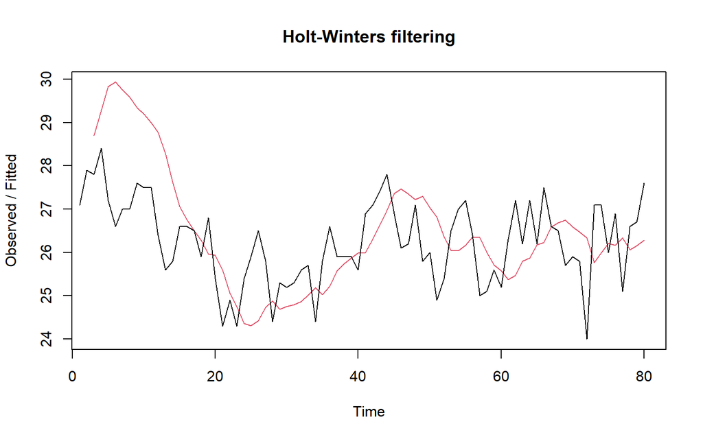

```r
#Lamda=0.2 dan gamma=0.2
des.1<- HoltWinters(train.ts, gamma = FALSE, beta = 0.2, alpha = 0.2)
plot(des.1)
```

```r
#ramalan
ramalandes1<- forecast(des.1, h=20)
ramalandes1
```

```
##     Point Forecast    Lo 80    Hi 80    Lo 95    Hi 95
##  81       26.61457 25.06073 28.16841 24.23818 28.99096
##  82       26.68272 25.08476 28.28068 24.23885 29.12659
##  83       26.75087 25.09474 28.40700 24.21803 29.28370
##  84       26.81902 25.08985 28.54818 24.17449 29.46355
##  85       26.88717 25.06978 28.70456 24.10771 29.66663
##  86       26.95532 25.03458 28.87605 24.01781 29.89283
##  87       27.02347 24.98468 29.06226 23.90541 30.14152
##  88       27.09162 24.92069 29.26255 23.77147 30.41177
##  89       27.15977 24.84335 29.47619 23.61711 30.70242
##  90       27.22792 24.75346 29.70238 23.44356 31.01228
##  91       27.29607 24.65180 29.94033 23.25201 31.34012
##  92       27.36422 24.53914 30.18930 23.04363 31.68481
##  93       27.43237 24.41616 30.44858 22.81948 32.04526
##  94       27.50052 24.28351 30.71753 22.58053 32.42051
##  95       27.56867 24.14176 30.99558 22.32767 32.80967
##  96       27.63682 23.99142 31.28222 22.06166 33.21197
##  97       27.70497 23.83295 31.57699 21.78323 33.62671
##  98       27.77312 23.66675 31.87949 21.49297 34.05327
##  99       27.84127 23.49319 32.18935 21.19145 34.49109
## 100       27.90942 23.31258 32.50626 20.87916 34.93968
```

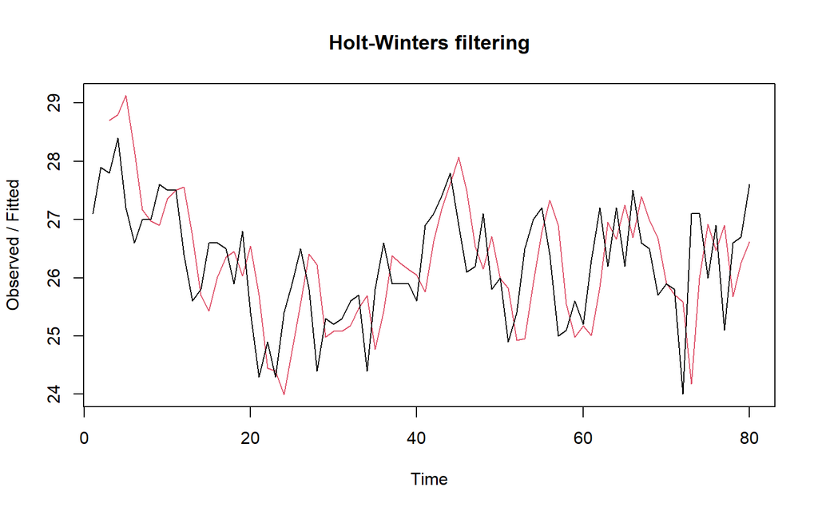

```r
#Lamda=0.6 dan gamma=0.3
des.2<- HoltWinters(train.ts, gamma = FALSE, beta = 0.3, alpha = 0.6)
plot(des.2)
```

```r
#ramalan
ramalandes2<- forecast(des.2, h=20)
ramalandes2
```

```
##     Point Forecast    Lo 80    Hi 80    Lo 95    Hi 95
##  81       27.48412 26.23959 28.72866 25.58078 29.38747
##  82       27.76064 26.18229 29.33899 25.34677 30.17452
##  83       28.03716 26.05761 30.01671 25.00970 31.06462
##  84       28.31368 25.87821 30.74915 24.58895 32.03840
##  85       28.59019 25.65247 31.52792 24.09733 33.08306
##  86       28.86671 25.38602 32.34740 23.54346 34.18996
##  87       29.14323 25.08285 33.20361 22.93341 35.35304
##  88       29.41974 24.74587 34.09362 22.27167 36.56782
##  89       29.69626 24.37735 35.01518 21.56169 37.83084
##  90       29.97278 23.97910 35.96646 20.80623 39.13933
##  91       30.24930 23.55261 36.94599 20.00759 40.49100
##  92       30.52581 23.09914 37.95249 19.16769 41.88393
##  93       30.80233 22.61978 38.98488 18.28820 43.31646
##  94       31.07885 22.11549 40.04221 17.37057 44.78712
##  95       31.35536 21.58710 41.12363 16.41609 46.29464
##  96       31.63188 21.03537 42.22840 15.42591 47.83785
##  97       31.90840 20.46098 43.35582 14.40108 49.41572
##  98       32.18492 19.86456 44.50528 13.34255 51.02728
##  99       32.46143 19.24666 45.67620 12.25119 52.67168
## 100       32.73795 18.60783 46.86807 11.12779 54.34811
```

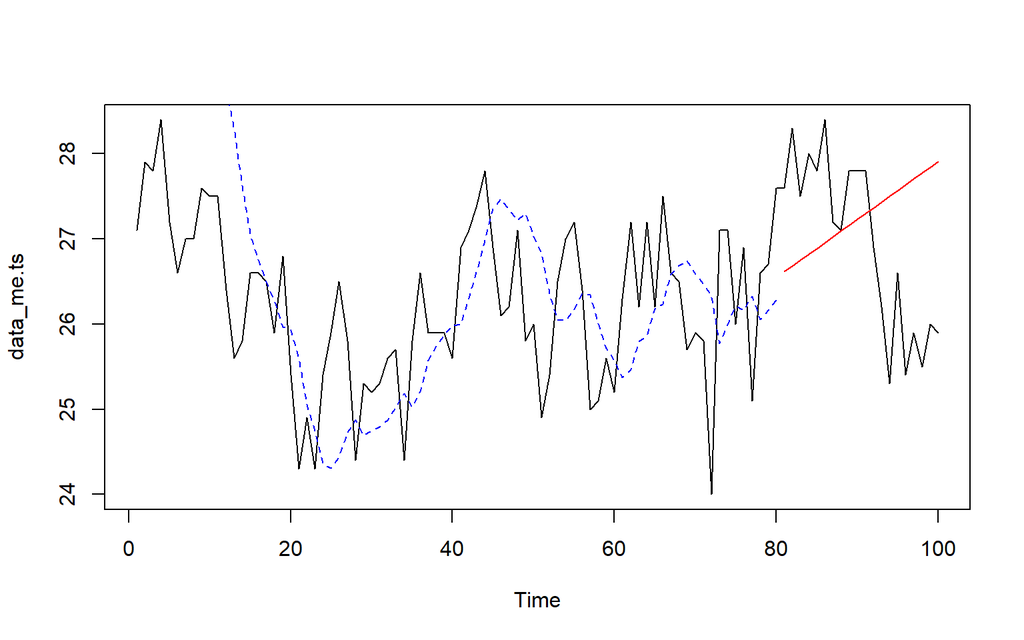

```r
plot(data_me.ts)
lines(des.1$fitted[,1], lty=2, col="blue")
lines(ramalandes1$mean, col="red")
```

Untuk mendapatkan nilai parameter optimum dari DES, argumen `alpha` dan `beta` dapat dibuat `NULL` seperti berikut.

```r
#Lamda dan gamma optimum
des.opt<- HoltWinters(train.ts, gamma = FALSE)
des.opt
```

```
## Holt-Winters exponential smoothing with trend and without seasonal component.
##
## Call:
## HoltWinters(x = train.ts, gamma = FALSE)
##
## Smoothing parameters:
##  alpha: 0.7548413
##  beta : 0.1187241
##  gamma: FALSE
##
## Coefficients:
##         [,1]
## a 27.3695869
## b  0.1347912
```

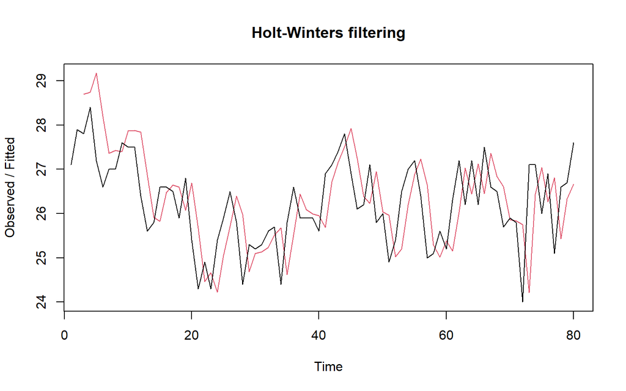

```r
plot(des.opt)
```

```r
#ramalan
ramalandesopt<- forecast(des.opt, h=20)
ramalandesopt
```

```
##     Point Forecast    Lo 80    Hi 80    Lo 95    Hi 95
##  81       27.50438 26.30786 28.70090 25.67446 29.33430
##  82       27.63917 26.07310 29.20524 25.24407 30.03427
##  83       27.77396 25.84998 29.69794 24.83148 30.71644
##  84       27.90875 25.62796 30.18954 24.42058 31.39692
##  85       28.04354 25.40224 30.68485 24.00401 32.08307
##  86       28.17833 25.17032 31.18635 23.57797 32.77870
##  87       28.31313 24.93082 31.69543 23.14033 33.48592
##  88       28.44792 24.68294 32.21289 22.68989 34.20595
##  89       28.58271 24.42624 32.73917 22.22594 34.93948
##  90       28.71750 24.16046 33.27453 21.74812 35.68688
##  91       28.85229 23.88549 33.81909 21.25623 36.44835
##  92       28.98708 23.60129 34.37287 20.75023 37.22394
##  93       29.12187 23.30788 34.93587 20.23013 38.01361
##  94       29.25666 23.00530 35.50803 19.69603 38.81730
##  95       29.39146 22.69365 36.08926 19.14804 39.63487
##  96       29.52625 22.37300 36.67949 18.58630 40.46619
##  97       29.66104 22.04347 37.27860 18.01098 41.31110
##  98       29.79583 21.70517 37.88649 17.42223 42.16943
##  99       29.93062 21.35819 38.50304 16.82023 43.04101
## 100       30.06541 21.00267 39.12815 16.20515 43.92568
```

Selanjutnya akan dilakukan perhitungan akurasi pada data latih maupun data uji dengan ukuran akurasi SSE, MSE dan MAPE.